# Machine Learning with Network Data

## 5.3 DeepWalk: Random Walks as Sentences

**Perozzi et al. (2014)** drew an analogy between graphs and text: nodes are words, random walks are sentences, co-occurrence in a walk window is analogous to co-occurrence in a text context window.

**Algorithm**:

1. For each node $v$, generate $r$ random walks of length $\ell$ starting at $v$
2. Treat each walk as a “sentence” of node IDs
3. Run **skip-gram** with negative sampling: maximise
   $$\sum_{v \in V} \sum_{u \in \mathcal{N}_R(v)} \log \sigma(z_v^\top z_u)
   + \sum_{k=1}^K \mathbb{E}_{u_k \sim P_n} [\log \sigma(-z_v^\top z_{u_k})]$$

where $\mathcal{N}_R(v)$ is the multi-set of nodes in the walk neighbourhood of $v$ (within window $w$), and $P_n$ is the noise distribution for negative sampling.

**Why it works**: nodes that frequently co-occur on short random walks; meaning they are in the same community or tightly connected subgraph; get assigned similar embedding vectors. The skip-gram objective *factorises* the PMI (pointwise mutual information) matrix of co-occurrences.

## 5.4 Node2Vec: Interpolating BFS and DFS

DeepWalk uses uniform random walks. **Node2Vec** (Grover & Leskovec 2016) introduces a 2nd-order Markov bias controlled by two parameters:

- **Return parameter $p$**: probability of returning to the previous node (inversely proportional to $1/p$). High $p$ → less backtracking.
- **In-out parameter $q$**: controls BFS vs DFS. $q < 1$ → DFS (explore outward), $q > 1$ → BFS (stay local).

At node $v$, having arrived from node $u$, transition to $x$ with unnormalised probability:

$$\alpha_{pq}(u, x) = \begin{cases} 1/p & d(u, x) = 0 \;\text{(return)} \\ 1 & d(u, x) = 1 \;\text{(lateral)} \\ 1/q & d(u, x) = 2 \;\text{(outward)} \end{cases}$$

**Why this matters**:

- **BFS walks** ($q \gg 1$): explore the local neighbourhood. Nodes with similar local structure (same community) get similar embeddings. Captures **homophily**.
- **DFS walks** ($q \ll 1$): explore outward, sampling diverse parts of the graph. Nodes at the same *role* in different communities (e.g., all hub nodes) get similar embeddings. Captures **structural equivalence**.

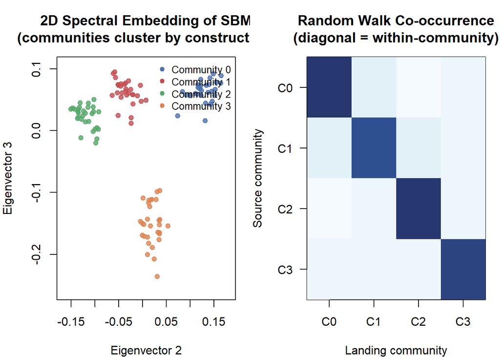

Spectral embedding of an SBM. Communities cluster clearly in 2D.

```r
set.seed(0)
k_emb  <- 4L; n_e <- 30L; n_emb <- k_emb * n_e
pref_e <- matrix(0.02, k_emb, k_emb); diag(pref_e) <- 0.3
g_emb  <- sample_sbm(n_emb, pref = pref_e, block.sizes = rep(n_e, k_emb))
true_labels_e <- rep(seq_len(k_emb) - 1L, each = n_e)

# Build normalised adjacency A_norm = D^{-1/2} A D^{-1/2}
A_e     <- as_adjacency_matrix(g_emb, sparse = TRUE)
deg_e   <- Matrix::rowSums(A_e)
d_isqrt <- ifelse(deg_e > 0, 1 / sqrt(deg_e), 0)
D_isqrt <- Diagonal(x = d_isqrt)
A_norm  <- D_isqrt %*% A_e %*% D_isqrt

# Top-5 singular vectors via RSpectra (or base svd on small graph)
# For small n use base svd; for large use RSpectra::svds
svd_res <- if (requireNamespace("RSpectra", quietly = TRUE)) {
  RSpectra::svds(A_norm, k = 5L)
} else {
  sv <- svd(as.matrix(A_norm), nu = 5L, nv = 5L)
  list(u = sv$u, d = sv$d, v = sv$v)
}
# Skip leading (trivial) eigenvector; take cols 2 and 3
emb <- svd_res$u[, 2:3, drop = FALSE]

# Random walk helper
random_walk <- function(g, start, len) {
  walk <- integer(len)
  walk[1] <- start
  for (i in seq_len(len - 1)) {
    nb <- neighbors(g, walk[i])
    if (length(nb) == 0) { walk <- walk[seq_len(i)]; break }
    walk[i + 1] <- sample(nb, 1L)
  }
  walk
}

par(mfrow = c(1, 2), mar = c(4, 4, 4, 1))

## (A) 2D spectral embedding
emb_cols <- c("#4C72B0", "#C44E52", "#55A868", "#DD8452")
plot(NULL, xlim = range(emb[, 1]) * 1.1, ylim = range(emb[, 2]) * 1.1,
     xlab = "Eigenvector 2", ylab = "Eigenvector 3",
     main = "2D Spectral Embedding of SBM\n(communities cluster by construction)")
for (cc in seq_len(k_emb)) {
  mask_c <- true_labels_e == (cc - 1L)
  points(emb[mask_c, 1], emb[mask_c, 2],
         pch = 19, cex = 0.9, col = adjustcolor(emb_cols[cc], 0.8))
}
legend("topright", legend = paste0("Community ", 0:(k_emb - 1)),
       col = emb_cols, pch = 19, bty = "n", cex = 0.85)

## (B) Random walk co-occurrence heatmap (4x4, aggregated by community)
set.seed(42)
n_walks  <- 30L; walk_len <- 15L; window <- 3L
walks    <- lapply(seq_len(n_emb), function(v)
  replicate(ceiling(n_walks / n_emb) + 1L,
            random_walk(g_emb, v, walk_len), simplify = FALSE))
walks    <- unlist(walks, recursive = FALSE)

cooc <- matrix(0, n_emb, n_emb)
for (w in walks) {
  lw <- length(w)
  for (i in seq_len(lw)) {
    js <- seq(max(1L, i - window), min(lw, i + window))
    js <- js[js != i]
    cooc[w[i], w[js]] <- cooc[w[i], w[js]] + 1L
  }
}

comm_cooc <- matrix(0, k_emb, k_emb)
for (u in seq_len(n_emb))
  for (v in seq_len(n_emb))
    comm_cooc[true_labels_e[u] + 1L, true_labels_e[v] + 1L] <-
      comm_cooc[true_labels_e[u] + 1L, true_labels_e[v] + 1L] + cooc[u, v]
comm_cooc <- comm_cooc / rowSums(comm_cooc)

image(t(comm_cooc[k_emb:1, ]), col = hcl.colors(20, "Blues", rev = TRUE),
      xaxt = "n", yaxt = "n",
      xlab = "Landing community", ylab = "Source community",
      main = "Random Walk Co-occurrence\n(diagonal = within-community)")
axis(1, at = seq(0, 1, length.out = k_emb), labels = paste0("C", 0:(k_emb-1)))
axis(2, at = seq(0, 1, length.out = k_emb), labels = paste0("C", (k_emb-1):0), las = 1)
```

```r
# Spectral embedding similarity: within vs cross community
within_sim <- c(); cross_sim <- c()
for (i in seq_len(n_emb)) {
  for (j in seq_len(n_emb)) {
    if (j <= i) next
    s <- sum(emb[i, ] * emb[j, ])
    if (true_labels_e[i] == true_labels_e[j]) within_sim <- c(within_sim, s)
    else                                       cross_sim  <- c(cross_sim,  s)
  }
}
cat(sprintf("Spectral embedding similarity:\n"))
```

```
Spectral embedding similarity:
```

```r
cat(sprintf("  Within-community: mean = %.4f\n",  mean(within_sim)))
```

```
  Within-community: mean = 0.0158
```

```r
cat(sprintf("  Cross-community:  mean = %.4f\n",  mean(cross_sim)))
```

```
  Cross-community:  mean = -0.0053
```

```r
cat(sprintf("  Separation ratio: %.2fx\n",
            mean(within_sim) / abs(mean(cross_sim))))
```

```
  Separation ratio: 3.00x
```

## 5.5 Limitations of Shallow Embeddings

All methods so far produce *transductive* embeddings: one vector per node, learned on a specific graph. They cannot:

- Embed new nodes without retraining
- Incorporate rich node features (text, demographics, sensor readings)
- Adapt to different downstream tasks (same embedding used for both link prediction and community detection)

This motivates **inductive** methods; specifically Graph Neural Networks.

# 6 Graph Neural Networks (GNNs)

## 6.1 The Core Idea: Learned Neighbourhood Aggregation

A GNN replaces the fixed aggregation of shallow methods with a *learnable* neighbourhood aggregation function:

$$h_v^{(l+1)} = \sigma\!\left(W^{(l)} \cdot \text{AGG}\!\left(\{h_u^{(l)} : u \in \mathcal{N}(v)\}\right) + B^{(l)} h_v^{(l)}\right)$$

where: - $h_v^{(0)} = x_v$ (node features, or a one-hot vector if none exist) - $W^{(l)}, B^{(l)}$ are learnable weight matrices, **shared across all nodes** - AGG is an aggregation function (mean, sum, max, attention-weighted) - $\sigma$ is a non-linearity (ReLU, etc.)

The sharing of weights across nodes is what makes GNNs **inductive**: the same function is applied to every node’s neighbourhood, so it generalises to unseen nodes with the same feature distribution.

## 6.2 Graph Convolutional Network (GCN, Kipf & Welling 2017)

The most widely used variant simplifies to:

$$H^{(l+1)} = \sigma\!\left(\hat{A} H^{(l)} W^{(l)}\right)$$

where $\hat{A} = \tilde{D}^{-1/2} \tilde{A} \tilde{D}^{-1/2}$ is the symmetrically normalised adjacency with added self-loops ($\tilde{A} = A + I$).

**Why self-loops?** Without them, $H^{(l+1)}_v$ depends only on neighbours, not on $v$ itself. The self-loop ensures each node *aggregates its own features* together with its neighbours’.

**Why symmetric normalisation?** It prevents the embeddings of high-degree nodes from having artificially large magnitudes and makes gradient flow more stable. It also corresponds to the Laplacian smoothing filter.

**Two-layer GCN for node classification** (fully written out):

$$Z = \text{softmax}\!\left(\hat{A} \cdot \text{ReLU}\!\left(\hat{A} X W^{(0)}\right) W^{(1)}\right)$$

Train by minimising cross-entropy on labelled nodes: $\mathcal{L} = -\sum_{i \in V_L} \sum_k y_{ik} \ln Z_{ik}$

## 6.3 GraphSAGE: Scalable Inductive Learning

GCN requires the full adjacency matrix $\hat{A}$ during training. For a graph with $10^6$ nodes, $\hat{A}$ is a $10^6 \times 10^6$ matrix; impossible to store or multiply with.

**GraphSAGE** (Hamilton, Ying & Leskovec 2017) introduces *neighbourhood sampling*: for each node, sample a fixed-size subset of $S$ neighbours instead of using all of them. This allows mini-batch training:

$$h_v^{(l+1)} = \sigma\!\left(W^{(l)} \left[ h_v^{(l)} \,\|\, \text{AGG}\!\left(\{h_u^{(l)} : u \in \tilde{\mathcal{N}}_S(v)\}\right) \right]\right)$$

(where $\|$ denotes concatenation and $\tilde{\mathcal{N}}_S(v)$ is a sampled neighbourhood of size $S$).

Because the weight matrices are *shared*, a trained GraphSAGE model can embed nodes that were not present during training; this is the inductive property.

## 6.4 Graph Attention Networks (GAT, Veličković et al. 2018)

Instead of uniform (mean) or fixed-normalisation (GCN) aggregation, GAT learns **attention weights** $\alpha_{ij}$ for each edge:

$$\alpha_{ij} = \frac{\exp\!\left(\text{LeakyReLU}(a^\top [W h_i \| W h_j])\right)}{\sum_{k \in \mathcal{N}(i)} \exp\!\left(\text{LeakyReLU}(a^\top [W h_i \| W h_k])\right)}$$

$$h_i^{\text{new}} = \sigma\!\left(\sum_{j \in \mathcal{N}(i)} \alpha_{ij} W h_j\right)$$

Attention weights are interpretable: a large $\alpha_{ij}$ means node $i$ relies heavily on node $j$ for its prediction.

**Multi-head attention**: run $K$ independent attention heads and concatenate (or average) the results. Reduces variance and captures diverse neighbourhood patterns.

## 6.5 The Message-Passing Framework

All GNN variants fit a single **message passing neural network (MPNN)** framework (Gilmer et al. 2017):

1. **Message**: $m_{ij}^{(l)} = \phi\!\left(h_i^{(l)}, h_j^{(l)}, e_{ij}\right)$
2. **Aggregate**: $a_i^{(l)} = \bigoplus_{j \in \mathcal{N}(i)} m_{ij}^{(l)}$
3. **Update**: $h_i^{(l+1)} = \gamma\!\left(h_i^{(l)}, a_i^{(l)}\right)$

The choice of $\phi$, $\bigoplus$, and $\gamma$ defines the GNN variant:

| Model | $\bigoplus$ | Notes |
| --- | --- | --- |
| GCN | Normalised sum | Fixed weights, simple |
| GraphSAGE | Mean / max | Sampled, inductive |
| GAT | Attention-weighted sum | Learnable weights |
| GIN | Sum | Most expressive (WL-equivalent) |

**GIN** (Xu et al. 2019) proves that sum aggregation is necessary for maximum expressiveness: mean and max aggregations can fail to distinguish different graph structures that sum can tell apart.

```r
build_a_hat <- function(A_dense) {
  n       <- nrow(A_dense)
  A_tilde <- A_dense + diag(n)
  d       <- rowSums(A_tilde)
  d_isqrt <- ifelse(d > 0, 1 / sqrt(d), 0)
  D_isqrt <- diag(d_isqrt)
  D_isqrt %*% A_tilde %*% D_isqrt
}

gcn_forward <- function(A_hat, X, W1, W2) {
  # Layer 1: ReLU(A_hat %*% X %*% W1)
  H1 <- A_hat %*% X %*% W1
  H1[H1 < 0] <- 0
  # Layer 2 + softmax
  Z  <- A_hat %*% H1 %*% W2
  Z  <- Z - apply(Z, 1, max)          # numerical stability
  Z  <- exp(Z)
  Z  / rowSums(Z)
}

set.seed(42)
k_gcn <- 3L; n_g <- 30L; n_gcn <- k_gcn * n_g
pref_g <- matrix(0.02, k_gcn, k_gcn); diag(pref_g) <- 0.3
g_gcn  <- sample_sbm(n_gcn, pref = pref_g, block.sizes = rep(n_g, k_gcn))
true_labels_g <- rep(seq_len(k_gcn) - 1L, each = n_g)

A_gcn <- as.matrix(as_adjacency_matrix(g_gcn, sparse = FALSE))
A_hat <- build_a_hat(A_gcn)

# Class-informative node features
means_g <- matrix(rnorm(k_gcn * 8) * 2, nrow = k_gcn)
X_gcn   <- means_g[true_labels_g + 1L, ] + matrix(rnorm(n_gcn * 8), n_gcn, 8)

# Random (untrained) weights
W1_gcn <- matrix(rnorm(8 * 16) * 0.1, 8, 16)
W2_gcn <- matrix(rnorm(16 * k_gcn) * 0.1, 16, k_gcn)

Z_gcn <- gcn_forward(A_hat, X_gcn, W1_gcn, W2_gcn)
cat(sprintf("GCN forward pass (untrained weights):\n"))
```

```
GCN forward pass (untrained weights):
```

```r
cat(sprintf("  Input features:    X shape = (%d, %d)\n",  nrow(X_gcn),  ncol(X_gcn)))
```

```
  Input features:    X shape = (90, 8)
```

```r
cat(sprintf("  After layer 1:     H1 shape = (%d, 16)\n", n_gcn))
```

```
  After layer 1:     H1 shape = (90, 16)
```

```r
cat(sprintf("  Output (logits):   Z shape = (%d, %d)\n",  nrow(Z_gcn),  ncol(Z_gcn)))
```

```
  Output (logits):   Z shape = (90, 3)
```

```r
cat("\nPredicted class probabilities for first 5 nodes:\n")
```

```
Predicted class probabilities for first 5 nodes:
```

```r
for (i in seq_len(5)) {
  cat(sprintf("  Node %d (true class %d): %s\n",
              i - 1L, true_labels_g[i],
              paste(round(Z_gcn[i, ], 3), collapse = "  ")))
}
```

```
  Node 0 (true class 0): 0.295  0.353  0.352
  Node 1 (true class 0): 0.295  0.351  0.354
  Node 2 (true class 0): 0.307  0.348  0.344
  Node 3 (true class 0): 0.3  0.346  0.354
  Node 4 (true class 0): 0.298  0.351  0.351
```

```r
# Effect of aggregation depth
cat("\n--- Effect of aggregation depth ---\n")
```

```
--- Effect of aggregation depth ---
```

```r
for (depth in 0:2) {
  X_smooth <- X_gcn
  for (d in seq_len(depth)) X_smooth <- A_hat %*% X_smooth
  within_var <- var(X_smooth[true_labels_g == 0, 1])
  cross_var  <- var(sapply(0:(k_gcn - 1), function(cc)
    mean(X_smooth[true_labels_g == cc, 1])))
  cat(sprintf("  Depth %d: within-class var=%.3f, between-class spread=%.3f, ratio=%.2f\n",
              depth, within_var, cross_var, cross_var / max(within_var, 1e-9)))
}
```

```
  Depth 0: within-class var=1.077, between-class spread=1.146, ratio=1.06
  Depth 1: within-class var=0.158, between-class spread=0.842, ratio=5.35
  Depth 2: within-class var=0.060, between-class spread=0.670, ratio=11.12
```

## 6.6 Practical Checklist: When to Use What

```
 Question
 Homophilic or heterophilic?
 Transductive or inductive?
 Node features available?
 How many GNN layers?
 Interpretability needed?
 Scale > 1M nodes?
 Overlapping communities?
 Recommendation
 Homophilic → GCN/GAT; Heterophilic → GraphSAGE or H2GCN
 Transductive → GCN (full graph); Inductive → GraphSAGE
 Yes: use them as x_v; No: use degree or identity matrix
 2-3 layers (deeper → over-smoothing, all nodes same vector)
 GAT (attention weights); GNN-Explainer for post-hoc
 Neighbour sampling (GraphSAGE, ClusterGCN, SIGN)
 NMF or BigCLAM; hard-partition methods miss overlaps
```

**ImportantOver-smoothing: the depth problem**

With $L$ GNN layers, each node aggregates information from its $L$-hop neighbourhood. For $L \gg 1$, every node’s representation converges to the same vector (proportional to the dominant eigenvector of $\hat{A}$). This *over-smoothing* destroys the discriminative signal.

In practice: **2 layers suffices for most tasks**. If deeper is needed, use skip connections (jumping knowledge networks) or residual connections.

# 7 Summary: ML on Networks

## 7.1 The Three-Problem Framework

```
 Task                Simplest method                Best ML method
 Community detection Louvain (modularity)           Leiden / DC-SBM inference
 Node classification Label propagation              GCN / GAT
 Link prediction     Common neighbours              Katz + GNN (dot product)
 Node embedding      Spectral (Laplacian eigenmaps) Node2Vec / GraphSAGE
 Key assumption         Main failure mode
 Modularity > 0         Resolution limit
 Homophily              Heterophily
 Triangle closure       Degree bias
 Proximity ~ similarity Transductive only
```

## 7.2 What Each Method Actually Optimises

| Method | Objective |
| --- | --- |
| Modularity (Louvain) | $\max_z \sum_c [m_c/m - (\kappa_c/2m)^2]$ |
| SBM MLE | $\max_{z,M} \ln \mathcal{L}(G \mid z, M)$ |
| Label propagation | Fixed point of $F = D^{-1}AF$ (with clamping) |
| GCN | $\min_W \mathcal{L}_{\text{CE}}(Z[V_L], y[V_L])$ |
| DeepWalk / Node2Vec | $\max_Z \sum_{(u,v) \in \text{walks}} \log \sigma(z_u^\top z_v)$ |
| Katz link prediction | $s(i,j) = [(I - \beta A)^{-1} - I]_{ij}$ |

## 7.3 References

- Blondel, V. D. et al. (2008). Fast unfolding of communities in large networks. *Journal of Statistical Mechanics*, P10008.
- Traag, V. A., Waltman, L. & van Eck, N. J. (2019). From Louvain to Leiden. *Scientific Reports*, 9, 5233.
- Zhu, X. & Ghahramani, Z. (2002). Learning from labeled and unlabeled data with label propagation. *CMU Technical Report* CMU-CALD-02-107.
- Adamic, L. A. & Adar, E. (2003). Friends and neighbors on the web. *Social Networks*, 25(3), 211–230.
- Perozzi, B., Al-Rfou, R. & Skiena, S. (2014). DeepWalk. *KDD 2014*.
- Grover, A. & Leskovec, J. (2016). Node2Vec. *KDD 2016*.
- Kipf, T. N. & Welling, M. (2017). Semi-supervised classification with graph convolutional networks. *ICLR 2017*.
- Hamilton, W. L., Ying, R. & Leskovec, J. (2017). Inductive representation learning on large graphs. *NeurIPS 2017*.
- Veličković, P. et al. (2018). Graph attention networks. *ICLR 2018*.
- Xu, K. et al. (2019). How powerful are graph neural networks? *ICLR 2019*.
- Gilmer, J. et al. (2017). Neural message passing for quantum chemistry. *ICML 2017*.
- Newman, M. E. J. (2013). *Networks: An Introduction*. Ch. 11–14.

Back to top